# Macro & Markets: Returns, Unemployment, and ML

Som Tripathi

## 0.1 Data: S&P 500 prices (Yahoo Finance)

We pull daily S&P 500 index prices (ticker `^GSPC`) from Yahoo Finance using `tidyquant`. This keeps the report reproducible because the data is retrieved directly in code.

```r
sp500_raw <- tq_get("^GSPC", from = "2000-01-01", get = "stock.prices")

# quick checks
dplyr::glimpse(sp500_raw)
```

```
## Rows: 6,527
## Columns: 8
## $ symbol   <chr> "^GSPC", "^GSPC", "^GSPC", "^GSPC", "^GSPC", "^GSPC", "^GSPC"…
## $ date     <date> 2000-01-03, 2000-01-04, 2000-01-05, 2000-01-06, 2000-01-07, …
## $ open     <dbl> 1469.25, 1455.22, 1399.42, 1402.11, 1403.45, 1441.47, 1457.60…
## $ high     <dbl> 1478.00, 1455.22, 1413.27, 1411.90, 1441.47, 1464.36, 1458.66…
## $ low      <dbl> 1438.36, 1397.43, 1377.68, 1392.10, 1400.73, 1441.47, 1434.42…
## $ close    <dbl> 1455.22, 1399.42, 1402.11, 1403.45, 1441.47, 1457.60, 1438.56…
## $ volume   <dbl> 931800000, 1009000000, 1085500000, 1092300000, 1225200000, 10…
## $ adjusted <dbl> 1455.22, 1399.42, 1402.11, 1403.45, 1441.47, 1457.60, 1438.56…
```

```r
dplyr::summarise(sp500_raw,
  start_date = min(date),
  end_date   = max(date),
  n_rows     = n()
)
```

```
## # A tibble: 1 × 3
##   start_date end_date   n_rows
##   <date>     <date>      <int>
## 1 2000-01-03 2025-12-12   6527
```

## 0.2 Cleaning: daily log returns

We compute daily log returns from the adjusted close price:

Return = log(adjusted_today / adjusted_yesterday)

This creates a stationary-ish series that’s easier to summarize and aggregate than raw prices.

```r
sp500_daily <- sp500_raw %>%
  arrange(date) %>%
  mutate(daily_log_return = log(adjusted / lag(adjusted))) %>%
  drop_na(daily_log_return)

# sanity checks
dplyr::summarise(sp500_daily,
  start_date = min(date),
  end_date   = max(date),
  n_rows     = n(),
  mean_return = mean(daily_log_return),
  sd_return   = sd(daily_log_return)
)
```

```
## # A tibble: 1 × 5
##   start_date end_date   n_rows mean_return sd_return
##   <date>     <date>      <int>       <dbl>     <dbl>
## 1 2000-01-04 2025-12-12   6526    0.000237    0.0122
```

## 0.3 Marginal summaries: daily market behavior

This section summarizes the distribution of daily returns and shows how the index level changes over time.

```r
# numeric summaries
sp500_daily %>%
  summarise(
    n_days = n(),
    min_return = min(daily_log_return),
    q05_return = quantile(daily_log_return, 0.05),
    median_return = median(daily_log_return),
    mean_return = mean(daily_log_return),
    q95_return = quantile(daily_log_return, 0.95),
    max_return = max(daily_log_return)
  )
```

```
## # A tibble: 1 × 7
##   n_days min_return q05_return median_return mean_return q95_return max_return
##    <int>      <dbl>      <dbl>         <dbl>       <dbl>      <dbl>      <dbl>
## 1   6526     -0.128    -0.0187      0.000642    0.000237     0.0170      0.110
```

# 1 price level over time

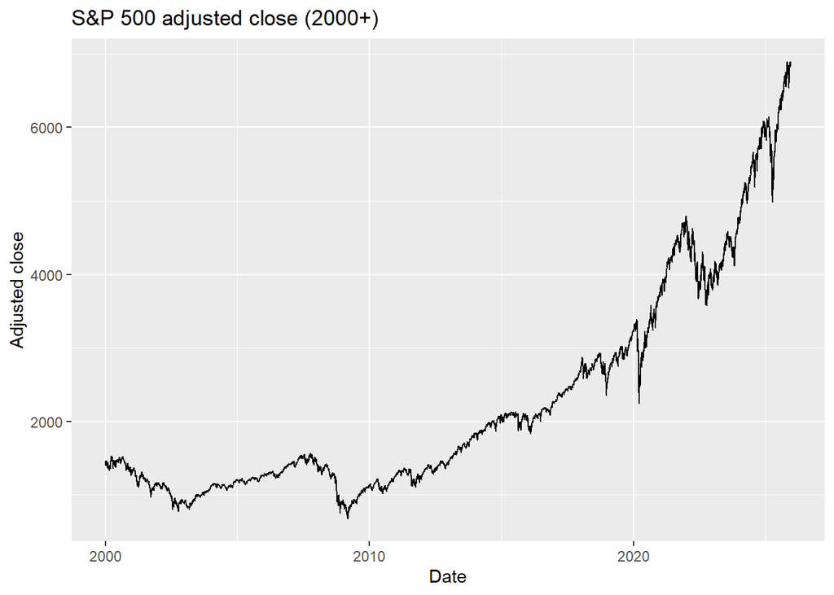

```r
sp500_raw %>%
ggplot(aes(x = date, y = adjusted)) +
geom_line() +
labs(
title = "S&P 500 adjusted close (2000+)",
x = "Date",
y = "Adjusted close"
)
```

# 2 distribution of daily log returns

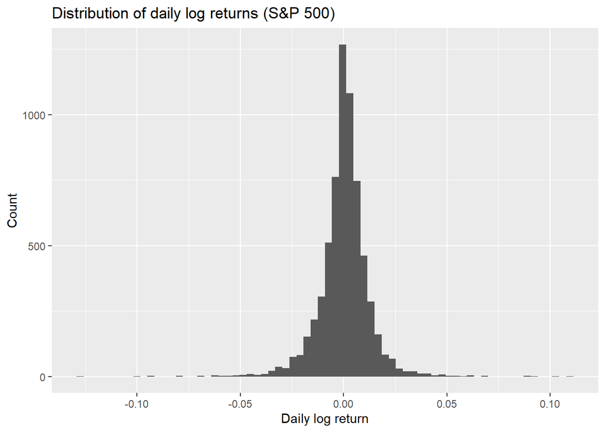

```r
sp500_daily %>%
ggplot(aes(x = daily_log_return)) +
geom_histogram(bins = 70) +
labs(
title = "Distribution of daily log returns (S&P 500)",
x = "Daily log return",
y = "Count"
)
```

## 2.1 Data: Unemployment rate (FRED)

We pull monthly U.S. unemployment data (series `UNRATE`) from FRED using `tidyquant`. This is measured in percent and is typically reported monthly.

```r
unemp_raw <- tq_get("UNRATE", from = "2000-01-01", get = "economic.data")

# quick checks
dplyr::glimpse(unemp_raw)
```

```
## Rows: 309
## Columns: 3
## $ symbol <chr> "UNRATE", "UNRATE", "UNRATE", "UNRATE", "UNRATE", "UNRATE", "UN…
## $ date   <date> 2000-01-01, 2000-02-01, 2000-03-01, 2000-04-01, 2000-05-01, 20…
## $ price  <dbl> 4.0, 4.1, 4.0, 3.8, 4.0, 4.0, 4.0, 4.1, 3.9, 3.9, 3.9, 3.9, 4.2…
```

```r
dplyr::summarise(unemp_raw,
  start_date = min(date),
  end_date   = max(date),
  n_rows     = n()
)
```

```
## # A tibble: 1 × 3
##   start_date end_date   n_rows
##   <date>     <date>      <int>
## 1 2000-01-01 2025-09-01    309
```

## 2.2 Cleaning + marginal summary: unemployment rate

`tidyquant` stores the unemployment series value in a column called `price`. We rename it to `unemployment_rate` to make the code easier to read.

```r
unemp_monthly <- unemp_raw %>%
  rename(unemployment_rate = price) %>%
  arrange(date)

# numeric summary
unemp_monthly %>%
  summarise(
    n_months = n(),
    min_unemp = min(unemployment_rate),
    q05_unemp = quantile(unemployment_rate, 0.05),
    median_unemp = median(unemployment_rate),
    mean_unemp = mean(unemployment_rate),
    q95_unemp = quantile(unemployment_rate, 0.95),
    max_unemp = max(unemployment_rate)
  )
```

```
## # A tibble: 1 × 7
##   n_months min_unemp q05_unemp median_unemp mean_unemp q95_unemp max_unemp
##      <int>     <dbl>     <dbl>        <dbl>      <dbl>     <dbl>     <dbl>
## 1      309       3.4       3.6            5       5.65       9.5      14.8
```

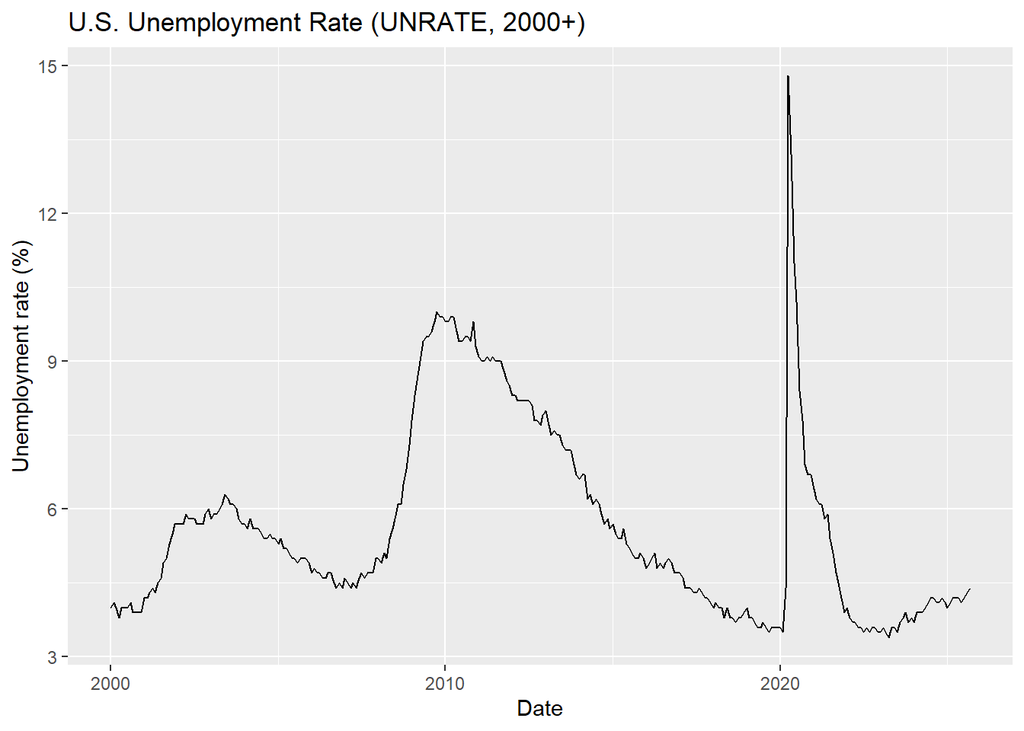

```r
unemp_monthly %>%
ggplot(aes(x = date, y = unemployment_rate)) +
geom_line() +
labs(
title = "U.S. Unemployment Rate (UNRATE, 2000+)",
x = "Date",
y = "Unemployment rate (%)"
)
```

## 2.3 Monthly market features + join with unemployment

Unemployment is monthly, so we aggregate daily S&P 500 returns to monthly features: - mean monthly log return (average of daily log returns within the month) - monthly volatility proxy (sd of daily log returns within the month)

Then we join on the month.

```r
sp500_monthly <- sp500_daily %>%
  mutate(month_date = floor_date(date, unit = "month")) %>%
  group_by(month_date) %>%
  summarise(
    mean_log_return = mean(daily_log_return),
    sd_log_return   = sd(daily_log_return),
    n_trading_days  = n(),
    .groups = "drop"
  )

macro_market_monthly <- sp500_monthly %>%
  inner_join(unemp_monthly, by = c("month_date" = "date"))
```

# 3 quick checks

```r
dplyr::glimpse(macro_market_monthly)
```

```
## Rows: 309
## Columns: 6
## $ month_date        <date> 2000-01-01, 2000-02-01, 2000-03-01, 2000-04-01, 200…
## $ mean_log_return   <dbl> -0.0022447293, -0.0010156501, 0.0040140761, -0.00164…
## $ sd_log_return     <dbl> 0.016806401, 0.012611965, 0.016749721, 0.021114560, …
## $ n_trading_days    <int> 19, 20, 23, 19, 22, 22, 20, 23, 20, 22, 21, 20, 21, …
## $ symbol            <chr> "UNRATE", "UNRATE", "UNRATE", "UNRATE", "UNRATE", "U…
## $ unemployment_rate <dbl> 4.0, 4.1, 4.0, 3.8, 4.0, 4.0, 4.0, 4.1, 3.9, 3.9, 3.…
```

```r
dplyr::summarise(macro_market_monthly,
  start_month = min(month_date),
  end_month   = max(month_date),
  n_months    = n()
)
```

```
## # A tibble: 1 × 3
##   start_month end_month  n_months
##   <date>      <date>        <int>
## 1 2000-01-01  2025-09-01      309
```

## 3.1 Joint relationships: unemployment vs returns and volatility

These plots show how monthly market behavior changes across unemployment conditions. Each point is one month.

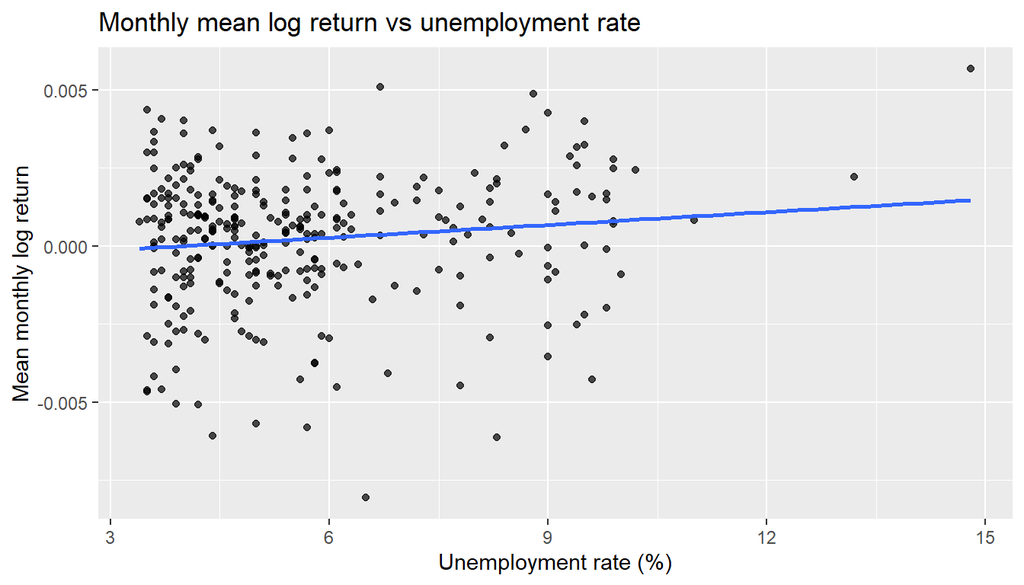

```r
# Returns vs unemployment
macro_market_monthly %>%
  ggplot(aes(x = unemployment_rate, y = mean_log_return)) +
  geom_point(alpha = 0.7) +
  geom_smooth(method = "lm", se = FALSE) +
  labs(
    title = "Monthly mean log return vs unemployment rate",
    x = "Unemployment rate (%)",
    y = "Mean monthly log return"
  )
```

# Volatility vs unemployment

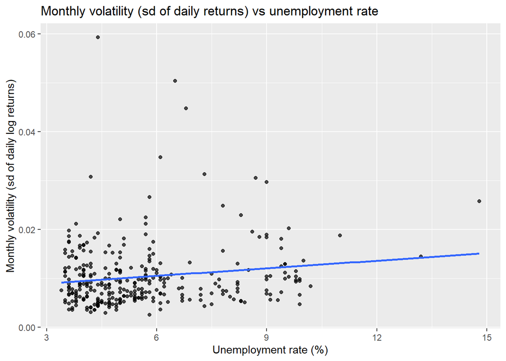

```r
macro_market_monthly %>%
  ggplot(aes(x = unemployment_rate, y = sd_log_return)) +
  geom_point(alpha = 0.7) +
  geom_smooth(method = "lm", se = FALSE) +
  labs(
    title = "Monthly volatility (sd of daily returns) vs unemployment rate",
    x = "Unemployment rate (%)",
    y = "Monthly volatility (sd of daily log returns)"
  )
```

## 3.2 Regimes: high vs low unemployment

To make the comparison clearer, we split months into “low” vs “high” unemployment. Here we use the median unemployment rate as the cutoff.

```r
cutoff <- median(macro_market_monthly$unemployment_rate)

macro_regime <- macro_market_monthly %>%
  mutate(
    unemp_regime = if_else(unemployment_rate > cutoff, "High unemployment", "Low unemployment")
  )
```

# 4 summary table by regime

```r
regime_summary <- macro_regime %>%
  group_by(unemp_regime) %>%
  summarise(
    n_months = n(),
    avg_return = mean(mean_log_return),
    avg_volatility = mean(sd_log_return),
    .groups = "drop"
  )

regime_summary
```

```
## # A tibble: 2 × 4
##   unemp_regime      n_months avg_return avg_volatility
##   <chr>                <int>      <dbl>          <dbl>
## 1 High unemployment      152   0.000326        0.0111
## 2 Low unemployment       157   0.000128        0.00962
```

# 5 compare returns by regime

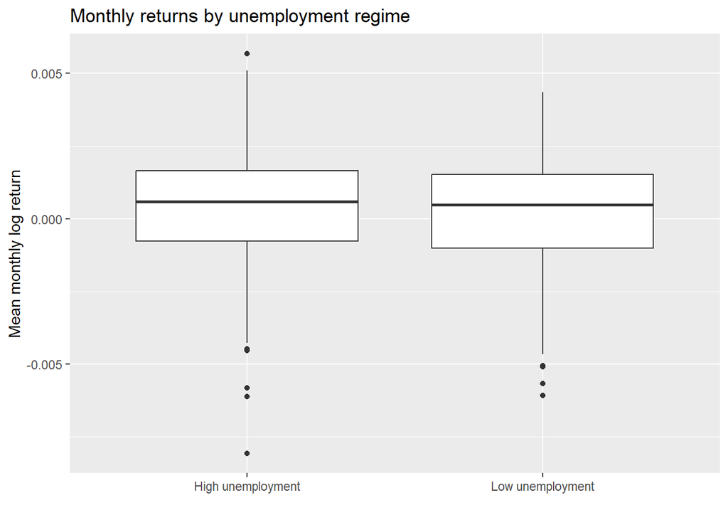

```r
macro_regime %>%
ggplot(aes(x = unemp_regime, y = mean_log_return)) +
geom_boxplot() +
labs(
title = "Monthly returns by unemployment regime",
x = "",
y = "Mean monthly log return"
)
```

# 6 compare volatility by regime

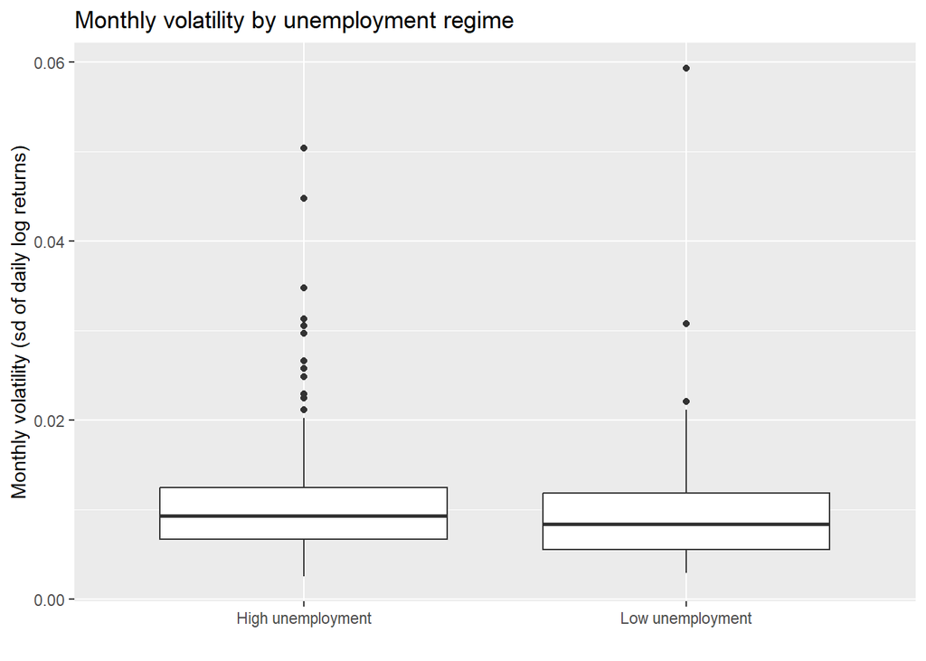

```r
macro_regime %>%
ggplot(aes(x = unemp_regime, y = sd_log_return)) +
geom_boxplot() +
labs(
title = "Monthly volatility by unemployment regime",
x = "",
y = "Monthly volatility (sd of daily log returns)"
)
```

## 6.1 ML setup: predict next month direction

We define a binary target: - `next_month_up = 1` if next month’s mean log return is positive, else 0.

Features use only information available in the current month: - unemployment_rate - change in unemployment (this month - last month) - current month return and volatility

We split by time (train on earlier years, test on later years) to avoid leakage.

```r
ml_data <- macro_market_monthly %>%
  arrange(month_date) %>%
  mutate(
    next_mean_log_return = lead(mean_log_return),
    next_month_up = if_else(next_mean_log_return > 0, 1, 0),
    unemp_change = unemployment_rate - lag(unemployment_rate)
  ) %>%
  drop_na(next_mean_log_return, unemp_change)
```

# 7 time split cutoff (feel free to change later)

```r
train_data <- ml_data %>% filter(year(month_date) <= 2015)
test_data  <- ml_data %>% filter(year(month_date) > 2015)
```

# 8 quick checks

```r
c(nrow(train_data), nrow(test_data))
```

```
## [1] 191 116
```

```r
test_data %>% summarise(up_rate = mean(next_month_up))
```

```
## # A tibble: 1 × 1
##   up_rate
##     <dbl>
## 1   0.690
```

## 8.1 Model 1: Logistic regression

We use logistic regression to estimate the probability that next month is “up”. This is a strong baseline because it’s simple, interpretable, and easy to reproduce.

```r
logit_fit <- glm(
  next_month_up ~ unemployment_rate + unemp_change + mean_log_return + sd_log_return,
  data = train_data,
  family = binomial()
)

summary(logit_fit)
```

```
##
## Call:
## glm(formula = next_month_up ~ unemployment_rate + unemp_change +
##     mean_log_return + sd_log_return, family = binomial(), data = train_data)
##
## Coefficients:
##                   Estimate Std. Error z value Pr(>|z|)
## (Intercept)       -0.20816    0.59290  -0.351    0.726
## unemployment_rate  0.10677    0.08732   1.223    0.221
## unemp_change      -0.56923    0.95313  -0.597    0.550
## mean_log_return   54.55436   79.32379   0.688    0.492
## sd_log_return     -8.27346   26.47040  -0.313    0.755
##
## (Dispersion parameter for binomial family taken to be 1)
##
##     Null deviance: 258.33  on 190  degrees of freedom
## Residual deviance: 254.88  on 186  degrees of freedom
## AIC: 264.88
##
## Number of Fisher Scoring iterations: 4
```

## 8.2 Evaluation: test performance + baseline

We evaluate on the held-out test period (years > 2015). We also compare against a simple baseline: always predict “up”.

```r
# predicted probabilities for "up"
test_probs <- predict(logit_fit, newdata = test_data, type = "response")

# classify using 0.5 threshold
test_pred <- if_else(test_probs >= 0.5, 1, 0)

# confusion matrix
table(
  Actual = test_data$next_month_up,
  Predicted = test_pred
)
```

```
##       Predicted
## Actual  0  1
##      0  7 29
##      1 11 69
```

```r
# accuracy
acc_model <- mean(test_pred == test_data$next_month_up)

# baseline: always predict up
baseline_pred <- rep(1, nrow(test_data))
acc_baseline <- mean(baseline_pred == test_data$next_month_up)

c(model_accuracy = acc_model, baseline_accuracy = acc_baseline)
```

```
##    model_accuracy baseline_accuracy
##         0.6551724         0.6896552
```

In the held-out test period, the logistic regression model achieved about 65.5% accuracy, while a naive baseline that always predicts an “up” month achieved about 69.0% accuracy. This indicates that the simple feature set used here (unemployment level, unemployment change, current-month return, and current-month volatility) does not provide strong predictive power for next-month market direction. This result is expected in real financial data because returns are noisy and many drivers are not captured in a small macro-only feature set. The model is still useful as a transparent baseline and as a demonstration of a time-respecting ML workflow.

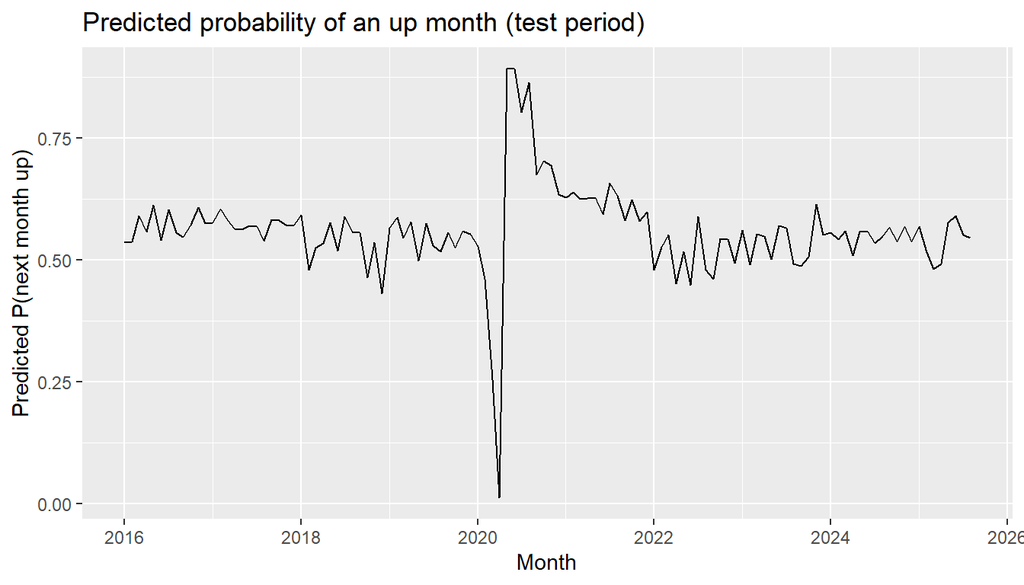

```r
test_plot_df <- test_data %>%
  mutate(pred_prob_up = test_probs)

test_plot_df %>%
  ggplot(aes(x = month_date, y = pred_prob_up)) +
  geom_line() +
  labs(
    title = "Predicted probability of an up month (test period)",
    x = "Month",
    y = "Predicted P(next month up)"
  )
```